# Bulk RNA-seq – Differential Expression Analysis with edgeR

Brain · Blood · Muscle (GTEx / recount3)

Giacomo Pogliana

2026-10-15

# 1 · Libraries and data loading

Raw recount3 data stores per-base coverage rather than read counts. `transform_counts()` converts coverage to integer counts by scaling each base-level value by the average read length, making the data suitable for count-based statistical models such as edgeR.

```r
library(recount3)
library(recount)
library(edgeR)

rse_brain  <- readRDS("rse_brain.RDS")
rse_blood  <- readRDS("rse_blood.RDS")
rse_muscle <- readRDS("rse_muscle.RDS")

# Convert coverage → counts
assays(rse_brain)$counts  <- transform_counts(rse_brain)
assays(rse_blood)$counts  <- transform_counts(rse_blood)
assays(rse_muscle)$counts <- transform_counts(rse_muscle)
```

# 2 · Sample quality control

Before selecting samples for downstream analysis, three QC metrics are inspected for each tissue:

- **RIN (RNA Integrity Number) ≥ 6** — a low RIN indicates RNA degradation, which introduces systematic biases in library preparation and reduces the reliability of expression estimates.
- **Uniquely mapped reads ≥ 80%** — a low mapping rate may reflect contamination, poor library quality, or a mismatch between the sample and the reference genome.
- **rRNA fraction < 10%** — high ribosomal RNA carry-over suggests incomplete ribo-depletion, which dilutes the mRNA signal and inflates library size without adding informative reads.

These thresholds follow GTEx consortium recommendations and standard bulk RNA-seq best practices.

## Brain

```r
# RIN
colData(rse_brain)$gtex.smrin[72:75]
```

```
## [1] 5.9 6.8 6.8 6.9
```

```r
# % mapped
colData(rse_brain)$"recount_qc.star.uniquely_mapped_reads_%_both"[72:75]
```

```
## [1] 90.3 88.4 89.1 91.8
```

```r
# % rRNA
colData(rse_brain)$gtex.smrrnart[72:75]
```

```
## [1] 0.1100480 0.0674476 0.0685402 0.0646821
```

## Blood

```r
colData(rse_blood)$gtex.smrin[72:74]
```

```
## [1] 7.6 8.6 7.3
```

```r
colData(rse_blood)$"recount_qc.star.uniquely_mapped_reads_%_both"[72:74]
```

```
## [1] 91.7 91.7 89.5
```

```r
colData(rse_blood)$gtex.smrrnart[72:74]
```

```
## [1] 0.00484823 0.00349803 0.00583278
```

## Muscle

```r
colData(rse_muscle)$gtex.smrin[72:75]
```

```
## [1] 7.8 8.5 5.7 8.2
```

```r
colData(rse_muscle)$"recount_qc.star.uniquely_mapped_reads_%_both"[72:75]
```

```
## [1] 90.9 89.8 92.0 92.5
```

```r
colData(rse_muscle)$gtex.smrrnart[72:75]
```

```
## [1] 0.00961303 0.00984120 0.00830360 0.01001430
```

# 3 · Sample selection and count matrix

Three samples per tissue that pass all QC thresholds are retained, giving a balanced design of **9 samples** (3 per group). The count matrices are concatenated column-wise into a single matrix `x`, and column/row names are assigned for readability.

Using three samples per group is a deliberate trade-off: it satisfies the minimum required for variance estimation in edgeR while keeping the design balanced — a critical requirement for the contrast-based comparisons performed later.

```r
rse_brain_selected  <- rse_brain[,  c(73, 74, 75)]
rse_blood_selected  <- rse_blood[,  c(72, 73, 74)]
rse_muscle_selected <- rse_muscle[, c(72, 73, 75)]

counts_brain_selected  <- assays(rse_brain_selected)$counts
counts_blood_selected  <- assays(rse_blood_selected)$counts
counts_muscle_selected <- assays(rse_muscle_selected)$counts

x <- cbind(counts_brain_selected, counts_blood_selected, counts_muscle_selected)

colnames(x) <- c("Brain73",  "Brain74",  "Brain75",
                 "Blood72",  "Blood73",  "Blood74",
                 "Muscle72", "Muscle73", "Muscle75")

rownames(x) <- rowData(rse_brain_selected)$gene_name
```

# 4 · DGEList object

The count matrix is wrapped into a `DGEList` object, which is edgeR’s core data structure. It bundles counts, library sizes, and sample-level metadata in one place, simplifying downstream function calls.

Alongside the tissue group label, additional QC covariates (RIN, tissue sub-region, sex, age, rRNA fraction, mapping rate, mitochondrial read fraction) are stored in `y$samples`. These are not included in the statistical model, but are used in the MDS plots (Section 8) to visually assess whether any of them drive unwanted variance.

```r
y <- DGEList(counts = x)

group <- as.factor(c("Brain", "Brain", "Brain",
                     "Blood", "Blood", "Blood",
                     "Muscle", "Muscle", "Muscle"))

y$samples$group <- group

# Quality metadata
y$samples$rin <- as.factor(c(
  colData(rse_brain_selected)$gtex.smrin,
  colData(rse_blood_selected)$gtex.smrin,
  colData(rse_muscle_selected)$gtex.smrin))

y$samples$slice <- as.factor(c(
  colData(rse_brain_selected)$gtex.smtsd,
  colData(rse_blood_selected)$gtex.smtsd,
  colData(rse_muscle_selected)$gtex.smtsd))

y$samples$sex <- as.factor(c(
  colData(rse_brain_selected)$gtex.sex,
  colData(rse_blood_selected)$gtex.sex,
  colData(rse_muscle_selected)$gtex.sex))

y$samples$age <- as.factor(c(
  colData(rse_brain_selected)$gtex.age,
  colData(rse_blood_selected)$gtex.age,
  colData(rse_muscle_selected)$gtex.age))

y$samples$rRNA <- as.factor(c(
  colData(rse_brain_selected)$gtex.smrrnart,
  colData(rse_blood_selected)$gtex.smrrnart,
  colData(rse_muscle_selected)$gtex.smrrnart))

y$samples$mapped <- as.factor(c(
  colData(rse_brain_selected)$"recount_qc.star.uniquely_mapped_reads_%_both",
  colData(rse_blood_selected)$"recount_qc.star.uniquely_mapped_reads_%_both",
  colData(rse_muscle_selected)$"recount_qc.star.uniquely_mapped_reads_%_both"))

y$samples$chrm <- as.factor(c(
  colData(rse_brain_selected)$"recount_qc.aligned_reads%.chrm",
  colData(rse_blood_selected)$"recount_qc.aligned_reads%.chrm",
  colData(rse_muscle_selected)$"recount_qc.aligned_reads%.chrm"))

y
```

```
## An object of class "DGEList"
## $counts
##              Brain73 Brain74 Brain75 Blood72 Blood73 Blood74 Muscle72 Muscle73
## SNX18P15           0       0       0       0       0       0        0        0
## SNX18P16           0       0       0       0       0       0        0        0
## ANKRD20A12P        0       0       0       0       0       0        0        0
## ANKRD20A15P        0       0       0       0       0       0        0        0
## LOC105379272       0       0       0       0       0       0        0        0
##              Muscle75
## SNX18P15            0
## SNX18P16            0
## ANKRD20A12P         0
## ANKRD20A15P         0
## LOC105379272        0
## 54037 more rows ...
##
## $samples
##           group lib.size norm.factors rin
## Brain73   Brain 29649400            1 6.8
## Brain74   Brain 27223813            1 6.8
## Brain75   Brain 31066981            1 6.9
## Blood72   Blood 34105714            1 7.6
## Blood73   Blood 34771177            1 8.6
## Blood74   Blood 32681771            1 7.3
## Muscle72 Muscle 29960906            1 7.8
## Muscle73 Muscle 29955791            1 8.5
## Muscle75 Muscle 30438386            1 8.2
##                                              slice sex   age       rRNA mapped
## Brain73  Brain - Nucleus accumbens (basal ganglia)   1 60-69  0.0674476   88.4
## Brain74            Brain - Putamen (basal ganglia)   1 60-69  0.0685402   89.1
## Brain75                   Brain - Substantia nigra   1 60-69  0.0646821   91.8
## Blood72                            Artery - Tibial   1 60-69 0.00484823   91.7
## Blood73                          Artery - Coronary   1 40-49 0.00349803   91.7
## Blood74                          Artery - Coronary   2 60-69 0.00583278   89.5
## Muscle72                         Muscle - Skeletal   1 60-69 0.00961303   90.9
## Muscle73                         Muscle - Skeletal   1 30-39  0.0098412   89.8
## Muscle75                         Muscle - Skeletal   1 50-59  0.0100143   92.5
##           chrm
## Brain73  22.68
## Brain74  27.46
## Brain75  22.85
## Blood72    4.9
## Blood73   5.93
## Blood74   10.3
## Muscle72 19.39
## Muscle73 21.39
## Muscle75 18.44
```

# 5 · Low-expression gene filtering

Genes with very low or zero counts across all samples carry no statistical power and inflate the multiple-testing burden. Two complementary checks are applied:

1. Genes with zero counts in **all 9 samples** are identified first as a diagnostic step.
2. `filterByExpr()` applies edgeR’s recommended filtering strategy: a gene is retained only if it achieves a minimum count (default ~10 reads) in at least as many samples as the smallest group size (here, 3). This threshold is automatically scaled by library size, making it robust across datasets with different sequencing depths.

Setting `keep.lib.sizes = FALSE` forces recalculation of library sizes after filtering, ensuring accurate normalization factors in the next step.

```r
table(rowSums(y$counts == 0) == 9)
```

```
##
## FALSE  TRUE
## 38471 15571
```

```r
keep.exprs <- filterByExpr(y, group = group)
y          <- y[keep.exprs, , keep.lib.sizes = FALSE]
dim(y)
```

```
## [1] 22333     9
```

# 6 · TMM normalization

RNA-seq library sizes differ across samples due to technical variation in sequencing depth. Raw counts therefore cannot be directly compared. **TMM (Trimmed Mean of M-values)** normalization estimates a scaling factor for each sample by computing a weighted trimmed mean of log fold-changes relative to a reference sample, after excluding genes with extreme expression differences (trimming). These scaling factors are stored in `y$samples$norm.factors` and incorporated automatically into all downstream edgeR calculations.

The boxplots before and after normalization allow a visual check that the distributions are well-aligned after scaling, as expected.

```r
logcpm_before <- cpm(y, log = TRUE)
y             <- normLibSizes(y, method = "TMM")
logcpm_after  <- cpm(y, log = TRUE)
y
```

```
## An object of class "DGEList"
## $counts
##              Brain73 Brain74 Brain75 Blood72 Blood73 Blood74 Muscle72 Muscle73
## WASH7P           995     996    1076     688     709    1148      714      624
## SEPT14P18         14      12      14      25       9      19       17        8
## LOC729737        209     186     217     433     466     374       94       67
## LOC102723897     677     769    1181     698     612    1125      589      613
## RPL23AP21         71      57     135      46      76      61        6       20
##              Muscle75
## WASH7P            604
## SEPT14P18          10
## LOC729737         106
## LOC102723897      546
## RPL23AP21           8
## 22328 more rows ...
##
## $samples
##           group lib.size norm.factors rin
## Brain73   Brain 29587519    1.3318366 6.8
## Brain74   Brain 27171059    1.3034400 6.8
## Brain75   Brain 31016252    1.2868309 6.9
## Blood72   Blood 34072837    1.0353899 7.6
## Blood73   Blood 34730143    1.1968015 8.6
## Blood74   Blood 32642371    1.3319016 7.3
## Muscle72 Muscle 29943253    0.6838964 7.8
## Muscle73 Muscle 29940392    0.6046998 8.5
## Muscle75 Muscle 30420554    0.6558555 8.2
##                                              slice sex   age       rRNA mapped
## Brain73  Brain - Nucleus accumbens (basal ganglia)   1 60-69  0.0674476   88.4
## Brain74            Brain - Putamen (basal ganglia)   1 60-69  0.0685402   89.1
## Brain75                   Brain - Substantia nigra   1 60-69  0.0646821   91.8
## Blood72                            Artery - Tibial   1 60-69 0.00484823   91.7
## Blood73                          Artery - Coronary   1 40-49 0.00349803   91.7
## Blood74                          Artery - Coronary   2 60-69 0.00583278   89.5
## Muscle72                         Muscle - Skeletal   1 60-69 0.00961303   90.9
## Muscle73                         Muscle - Skeletal   1 30-39  0.0098412   89.8
## Muscle75                         Muscle - Skeletal   1 50-59  0.0100143   92.5
##           chrm
## Brain73  22.68
## Brain74  27.46
## Brain75  22.85
## Blood72    4.9
## Blood73   5.93
## Blood74   10.3
## Muscle72 19.39
## Muscle73 21.39
## Muscle75 18.44
```

## Log-CPM boxplots before and after normalization

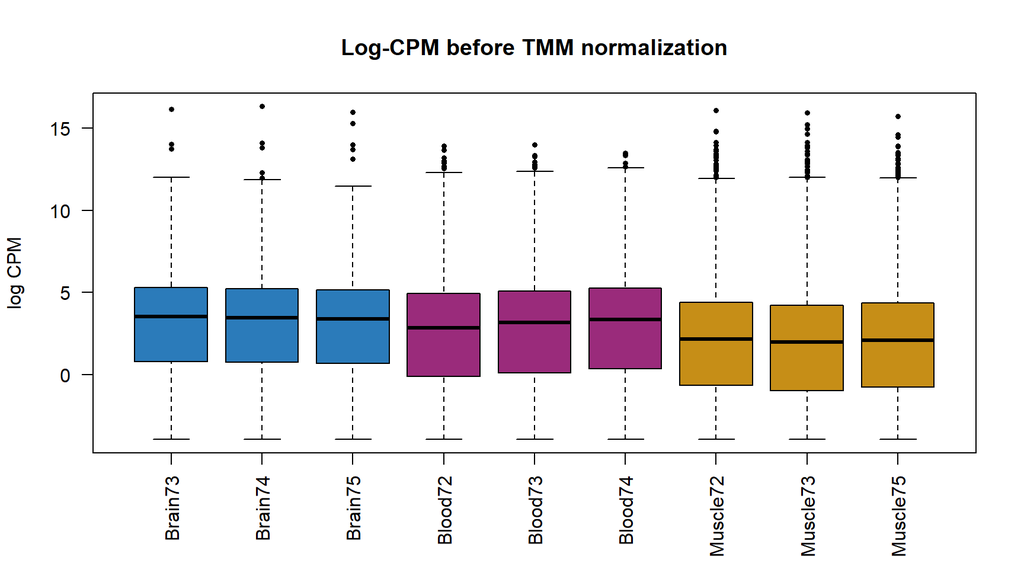

```r
tissue_cols <- c(
  rep("#2b7bba", 3),   # Brain
  rep("#9a2b7b", 3),   # Blood
  rep("#c68e17", 3)    # Muscle
)

boxplot(logcpm_before,
        col    = tissue_cols,
        notch  = FALSE,
        las    = 2,
        ylab   = "log CPM",
        outpch = 16,
        outcex = 0.6,
        main   = "Log-CPM before TMM normalization")
```

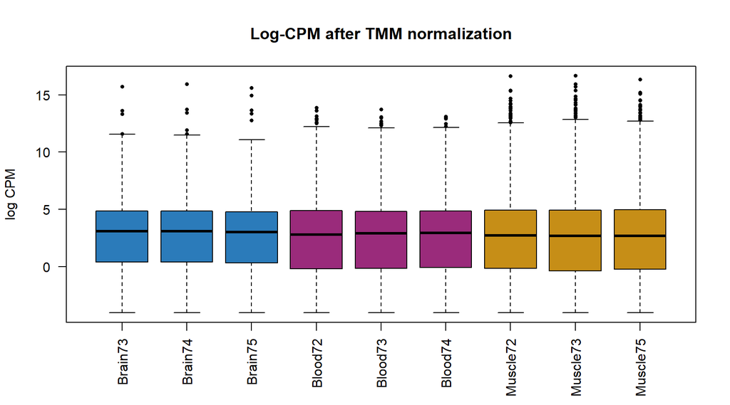

```r
boxplot(logcpm_after,
        col    = tissue_cols,
        notch  = FALSE,
        las    = 2,
        ylab   = "log CPM",
        outpch = 16,
        outcex = 0.6,
        main   = "Log-CPM after TMM normalization")
```

# 7 · Design matrix

The design matrix encodes the experimental structure that the linear model will fit. The formula `~ 0 + group` specifies an **intercept-free model** where each tissue type gets its own coefficient directly (rather than one group being encoded as the intercept). This parameterization makes it straightforward to define arbitrary contrasts between groups (e.g., Brain − Blood) without algebraic manipulation.

```r
design <- model.matrix(~ 0 + group, data = y$samples)
colnames(design) <- levels(y$samples$group)
design
```

```
##          Blood Brain Muscle
## Brain73      0     1      0
## Brain74      0     1      0
## Brain75      0     1      0
## Blood72      1     0      0
## Blood73      1     0      0
## Blood74      1     0      0
## Muscle72     0     0      1
## Muscle73     0     0      1
## Muscle75     0     0      1
## attr(,"assign")
## [1] 1 1 1
## attr(,"contrasts")
## attr(,"contrasts")$group
## [1] "contr.treatment"
```

# 8 · MDS plot – exploratory analysis of sample variability

**Multi-Dimensional Scaling (MDS)** projects samples into a low-dimensional space such that distances approximate the log2 fold-changes between pairs of samples for the top 500 most variable genes (by default). It provides an unsupervised, model-free look at the dominant sources of variance in the data before any formal testing.

Six plots are produced, labelling samples by tissue group and five potential confounders in turn (rRNA fraction, mitochondrial read fraction, age, sex, tissue sub-region). If any confounder label correlates with the spatial separation of samples along a major axis, it should be considered as a covariate in the model.

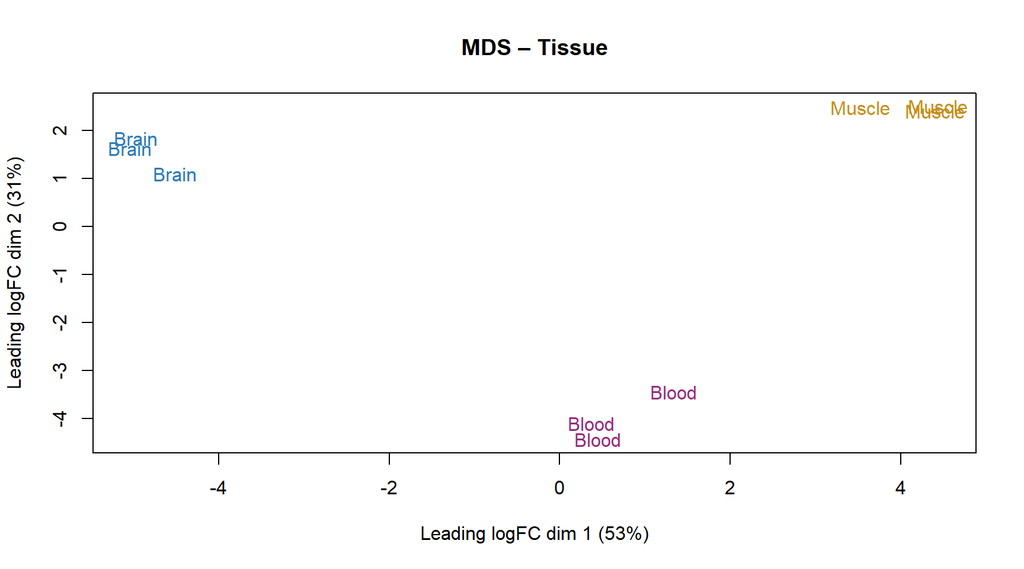

```r
logcpm <- cpm(y, log = TRUE)

plotMDS(logcpm, col = tissue_cols, labels = group,
        main = "MDS – Tissue")
```

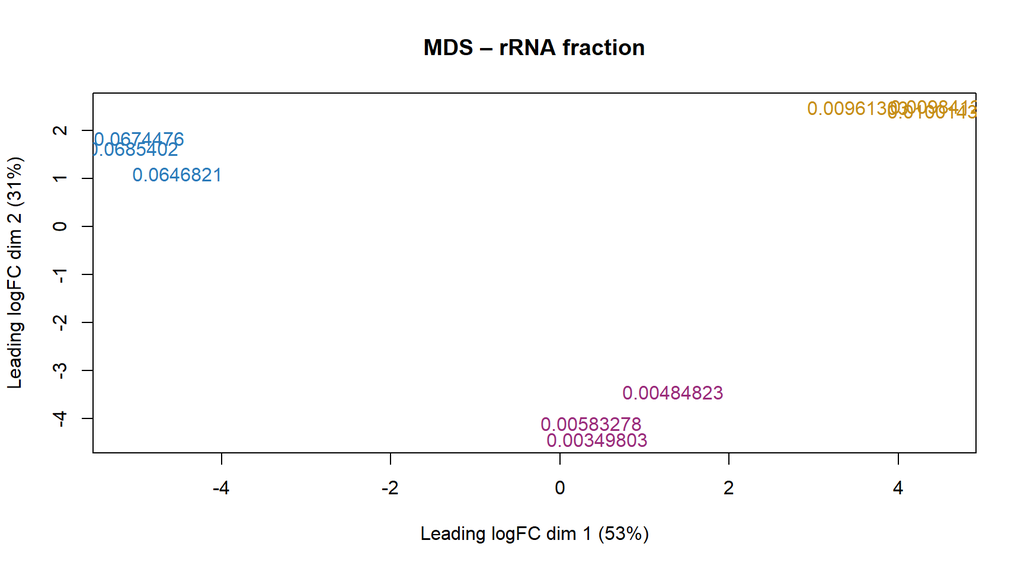

```r
plotMDS(logcpm, col = tissue_cols, labels = y$samples$rRNA,
        main = "MDS – rRNA fraction")
```

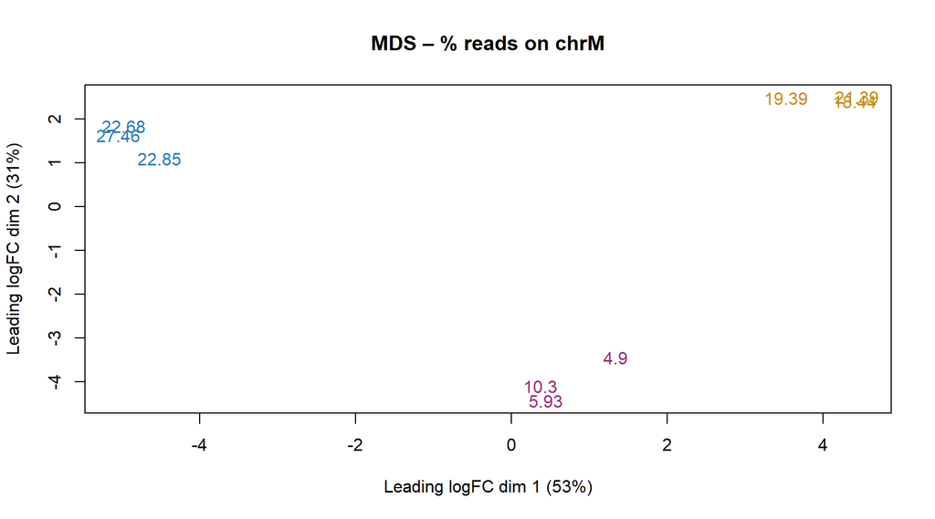

```r
plotMDS(logcpm, col = tissue_cols, labels = y$samples$chrm,
        main = "MDS – % reads on chrM")
```

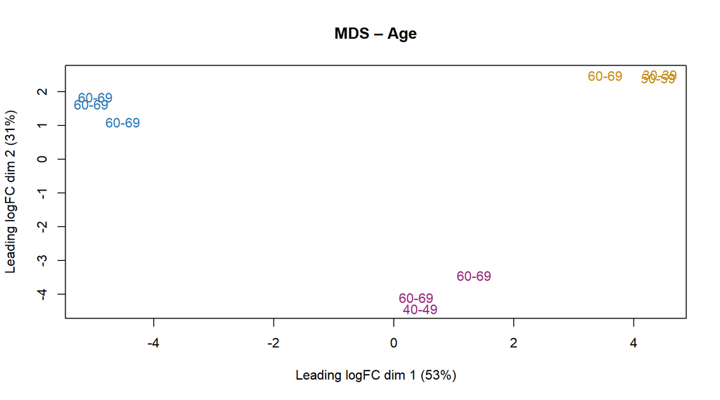

```r
plotMDS(logcpm, col = tissue_cols, labels = y$samples$age,
        main = "MDS – Age")
```

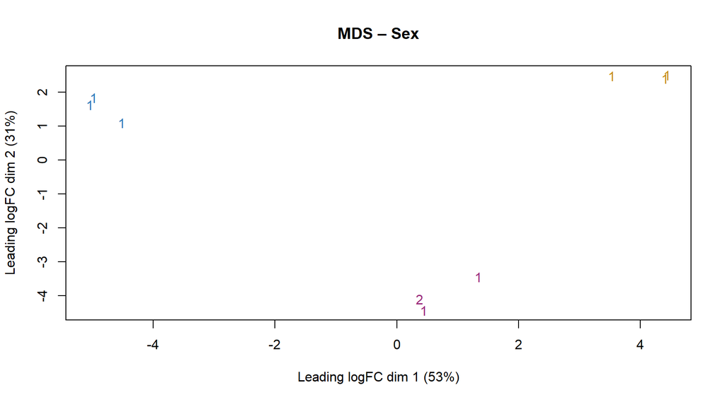

```r
plotMDS(logcpm, col = tissue_cols, labels = y$samples$sex,
        main = "MDS – Sex")
```

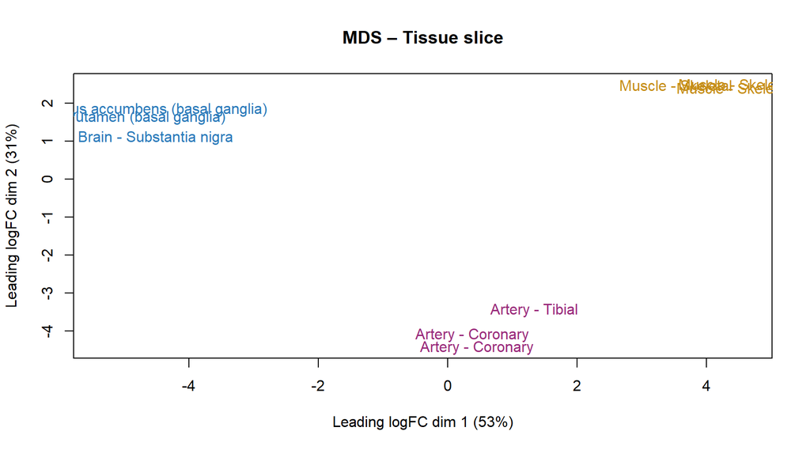

```r
plotMDS(logcpm, col = tissue_cols, labels = y$samples$slice,
        main = "MDS – Tissue slice")
```

# 9 · Dispersion estimation

edgeR models read counts with a **Negative Binomial (NB) distribution**, which has two parameters: the mean and the dispersion. The dispersion captures gene-to-gene variability in count data beyond what a Poisson model (variance = mean) would predict.

`estimateDisp()` fits both a common dispersion (shared across all genes) and gene-wise dispersions, shrinking them toward a trended value via empirical Bayes. The **BCV (Biological Coefficient of Variation) plot** shows the square root of the dispersion estimates: the trend line summarizes how dispersion varies with expression level (highly expressed genes tend to have lower BCV), and the gene-wise estimates scatter around it.

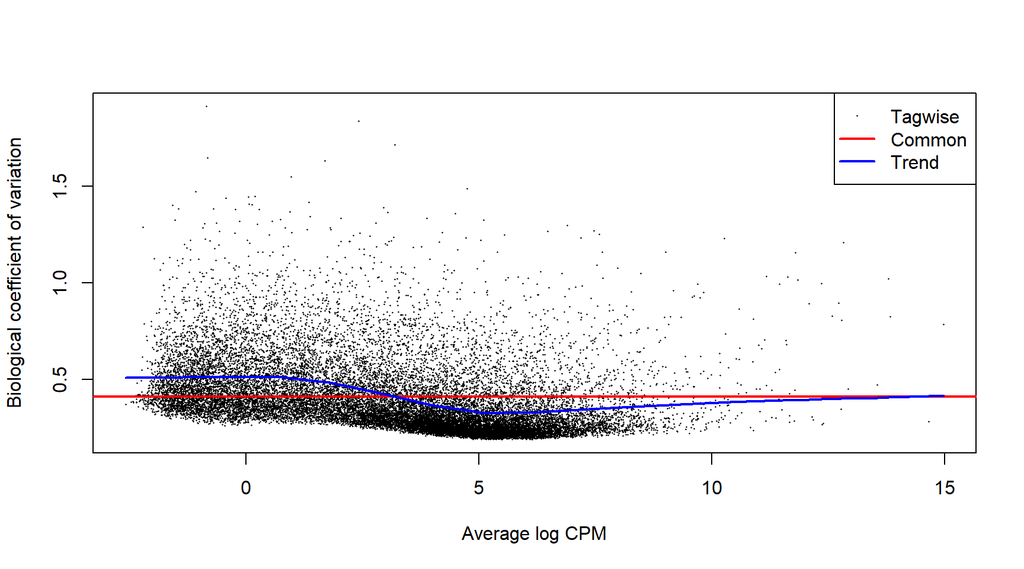

```r
y <- estimateDisp(y, design)
plotBCV(y)
```

# 10 · Differential expression – GLM QL F-test

A **Quasi-Likelihood (QL) Negative Binomial GLM** is fitted to the data. Compared to the standard likelihood ratio test, the QL framework provides a more robust control of type I error, particularly with small sample sizes, by using a gene-level quasi-dispersion estimate that is itself moderated across genes with empirical Bayes.

Three pairwise contrasts are tested:

[output not shown]

The coefficient order follows the alphabetical ordering of the group factor levels: **Blood, Brain, Muscle**.

```r
fit <- glmQLFit(y, design)

# Brain vs Blood
qlfBLB <- glmQLFTest(fit, contrast = c(-1,  1,  0))
# Muscle vs Blood
qlfMB  <- glmQLFTest(fit, contrast = c(-1,  0,  1))
# Muscle vs Brain
qlfMBL <- glmQLFTest(fit, contrast = c( 0, -1,  1))
```

## Top 10 differentially expressed genes per contrast

Results are ranked by p-value and FDR-corrected with the Benjamini–Hochberg (BH) method, which controls the false discovery rate.

```r
topTags(qlfBLB, n = 10, adjust.method = "BH", sort.by = "PValue")
```

```
## Coefficient:  -1*Blood 1*Brain
##                  logFC   logCPM        F       PValue          FDR
## GDAP1L1       8.659285 2.358325 536.9216 2.020339e-12 4.512024e-08
## LOC112268271  9.973783 2.798653 279.5947 8.508306e-12 6.596861e-08
## AMER2        13.157012 5.964481 497.3767 1.037608e-11 6.596861e-08
## TMEM151A     11.568621 5.241597 470.8248 1.181545e-11 6.596861e-08
## STXBP5L       8.968066 2.299378 320.0386 5.778139e-11 2.580864e-07
## GPR143        7.478507 1.500826 256.8836 1.217670e-10 2.754660e-07
## OPALIN       14.183648 6.236008 389.9343 1.227943e-10 2.754660e-07
## CCEPR         8.860168 2.844100 278.0098 1.276017e-10 2.754660e-07
## SYT4         10.248575 3.923221 369.9294 1.355668e-10 2.754660e-07
## TMEM235      11.848323 4.657277 228.5234 1.521523e-10 2.754660e-07
```

```r
topTags(qlfMB,  n = 10, adjust.method = "BH", sort.by = "PValue")
```

```
## Coefficient:  -1*Blood 1*Muscle
##                  logFC   logCPM        F       PValue          FDR
## ART1         10.047649 4.455877 832.2992 1.540044e-11 3.439380e-07
## LINGO4        9.748272 3.415510 352.5543 7.425959e-11 4.355082e-07
## LOC101929592 10.326128 4.740777 341.8651 7.774368e-11 4.355082e-07
## LRRC14B      11.687620 5.369562 488.2746 7.800264e-11 4.355082e-07
## FBP2         10.970570 7.298082 321.6718 1.588480e-10 7.095106e-07
## MAMSTR        6.340329 5.492351 737.6897 2.816057e-10 8.121742e-07
## ADPRHL1       7.475412 6.432315 732.7271 2.906439e-10 8.121742e-07
## KCNA7        10.975523 4.938030 322.5573 3.227050e-10 8.121742e-07
## DHRS7C       13.223855 5.279392 320.7218 3.272990e-10 8.121742e-07
## ATP2A1-AS1   10.575071 6.124066 657.5457 5.005707e-10 1.117925e-06
```

```r
topTags(qlfMBL, n = 10, adjust.method = "BH", sort.by = "PValue")
```

```
## Coefficient:  -1*Brain 1*Muscle
##                   logFC   logCPM         F       PValue          FDR
## GDAP1L1       -7.697898 2.358325  424.3909 9.766308e-12 1.914928e-07
## ART1           9.807470 4.455877  815.6339 1.714886e-11 1.914928e-07
## TMEM151A     -10.306542 5.241597  401.2444 3.272948e-11 1.948023e-07
## LOC112268271  -9.073897 2.798653  226.9863 4.318224e-11 1.948023e-07
## LOC101929592  11.390409 4.740777  357.0300 5.891945e-11 1.948023e-07
## FBP2          14.440811 7.298082  376.5454 5.928592e-11 1.948023e-07
## FBXO2         -8.282455 5.988177 1042.6269 6.105836e-11 1.948023e-07
## YBX3P1         8.964050 5.965620  964.4319 8.591127e-11 2.165995e-07
## LINGO4         9.403148 3.415510  343.6643 8.728766e-11 2.165995e-07
## AMER2         -8.030018 5.964481  327.8326 1.423231e-10 3.178503e-07
```

## Saving full results tables

```r
resultsBLB <- topTags(qlfBLB, n = Inf, adjust.method = "BH",
                      sort.by = "PValue", p.value = 1)
resultsMB  <- topTags(qlfMB,  n = Inf, adjust.method = "BH",
                      sort.by = "PValue", p.value = 1)
resultsMBL <- topTags(qlfMBL, n = Inf, adjust.method = "BH",
                      sort.by = "PValue", p.value = 1)

write.table(resultsBLB, "results_Brain_vs_Blood.txt")
write.table(resultsMB,  "results_Muscle_vs_Blood.txt")
write.table(resultsMBL, "results_Muscle_vs_Brain.txt")
```

## DE gene counts at different cut-offs

`decideTests()` classifies each gene as up-regulated, down-regulated, or not significant under a given FDR threshold and log-fold-change (lfc) cutoff. Comparing results across multiple thresholds (`p = 0.05 / 0.01`, `lfc = 0 / 1`) illustrates the sensitivity-specificity trade-off and helps choose a biologically meaningful stringency for downstream analyses.

```r
cat("--- Brain vs Blood ---\n")
```

```
## --- Brain vs Blood ---
```

```r
summary(decideTests(qlfBLB, p.value = 0.05, adjust.method = "BH", lfc = 0))
```

```
##        -1*Blood 1*Brain
## Down               5143
## NotSig            11376
## Up                 5814
```

```r
summary(decideTests(qlfBLB, p.value = 0.05, adjust.method = "BH", lfc = 1))
```

```
##        -1*Blood 1*Brain
## Down               4144
## NotSig            13085
## Up                 5104
```

```r
summary(decideTests(qlfBLB, p.value = 0.01, adjust.method = "BH", lfc = 0))
```

```
##        -1*Blood 1*Brain
## Down               3410
## NotSig            14742
## Up                 4181
```

```r
summary(decideTests(qlfBLB, p.value = 0.01, adjust.method = "BH", lfc = 1))
```

```
##        -1*Blood 1*Brain
## Down               3157
## NotSig            15145
## Up                 4031
```

```r
cat("\n--- Muscle vs Blood ---\n")
```

```
##
## --- Muscle vs Blood ---
```

```r
summary(decideTests(qlfMB, p.value = 0.05, adjust.method = "BH", lfc = 0))
```

```
##        -1*Blood 1*Muscle
## Down                5271
## NotSig             11981
## Up                  5081
```

```r
summary(decideTests(qlfMB, p.value = 0.05, adjust.method = "BH", lfc = 1))
```

```
##        -1*Blood 1*Muscle
## Down                4696
## NotSig             13438
## Up                  4199
```

```r
summary(decideTests(qlfMB, p.value = 0.01, adjust.method = "BH", lfc = 0))
```

```
##        -1*Blood 1*Muscle
## Down                3282
## NotSig             15543
## Up                  3508
```

```r
summary(decideTests(qlfMB, p.value = 0.01, adjust.method = "BH", lfc = 1))
```

```
##        -1*Blood 1*Muscle
## Down                3163
## NotSig             15864
## Up                  3306
```

```r
cat("\n--- Muscle vs Brain ---\n")
```

```
##
## --- Muscle vs Brain ---
```

```r
summary(decideTests(qlfMBL, p.value = 0.05, adjust.method = "BH", lfc = 0))
```

```
##        -1*Brain 1*Muscle
## Down                6539
## NotSig              9531
## Up                  6263
```

```r
summary(decideTests(qlfMBL, p.value = 0.05, adjust.method = "BH", lfc = 1))
```

```
##        -1*Brain 1*Muscle
## Down                5985
## NotSig             11250
## Up                  5098
```

```r
summary(decideTests(qlfMBL, p.value = 0.01, adjust.method = "BH", lfc = 0))
```

```
##        -1*Brain 1*Muscle
## Down                4912
## NotSig             12860
## Up                  4561
```

```r
summary(decideTests(qlfMBL, p.value = 0.01, adjust.method = "BH", lfc = 1))
```

```
##        -1*Brain 1*Muscle
## Down                4788
## NotSig             13346
## Up                  4199
```

# 11 · Tissue-specific genes

A gene is defined as **tissue-specific** if it is significantly up-regulated in that tissue relative to *both* other tissues (FDR < 0.01, logFC > 0). This conservative definition — requiring simultaneous significance in two independent comparisons — reduces false positives that would arise from testing only one pair.

The approach uses set intersection: a gene must appear in the up-regulated set of *both* pairwise contrasts involving the tissue of interest.

## Brain-specific

```r
qlf_BvsBlood  <- glmQLFTest(fit, contrast = c(-1,  1,  0))
qlf_BvsMuscle <- glmQLFTest(fit, contrast = c( 0,  1, -1))

results_BvsBlood  <- topTags(qlf_BvsBlood,  n = Inf)$table
results_BvsMuscle <- topTags(qlf_BvsMuscle, n = Inf)$table

up_BvsBlood  <- rownames(results_BvsBlood[ results_BvsBlood$FDR  < 0.01 & results_BvsBlood$logFC  > 0, ])
up_BvsMuscle <- rownames(results_BvsMuscle[results_BvsMuscle$FDR < 0.01 & results_BvsMuscle$logFC > 0, ])

brain_specific <- intersect(up_BvsBlood, up_BvsMuscle)
```

## Blood-specific

```r
qlf_BloodvsBrain  <- glmQLFTest(fit, contrast = c( 1, -1,  0))
qlf_BloodvsMuscle <- glmQLFTest(fit, contrast = c( 1,  0, -1))

results_BloodvsBrain  <- topTags(qlf_BloodvsBrain,  n = Inf)$table
results_BloodvsMuscle <- topTags(qlf_BloodvsMuscle, n = Inf)$table

up_BloodvsBrain  <- rownames(results_BloodvsBrain[ results_BloodvsBrain$FDR  < 0.01 & results_BloodvsBrain$logFC  > 0, ])
up_BloodvsMuscle <- rownames(results_BloodvsMuscle[results_BloodvsMuscle$FDR < 0.01 & results_BloodvsMuscle$logFC > 0, ])

blood_specific <- intersect(up_BloodvsBrain, up_BloodvsMuscle)
```

## Muscle-specific

```r
qlf_MusclevsBrain <- glmQLFTest(fit, contrast = c( 0, -1,  1))
qlf_MusclevsBlood <- glmQLFTest(fit, contrast = c(-1,  0,  1))

results_MusclevsBrain <- topTags(qlf_MusclevsBrain, n = Inf)$table
results_MusclevsBlood <- topTags(qlf_MusclevsBlood, n = Inf)$table

up_MusclevsBrain <- rownames(results_MusclevsBrain[results_MusclevsBrain$FDR < 0.01 & results_MusclevsBrain$logFC > 0, ])
up_MusclevsBlood <- rownames(results_MusclevsBlood[results_MusclevsBlood$FDR < 0.01 & results_MusclevsBlood$logFC > 0, ])

muscle_specific <- intersect(up_MusclevsBrain, up_MusclevsBlood)
```

## Summary and export

```r
print(paste("Tissue-specific genes – Brain:",  length(brain_specific)))
```

```
## [1] "Tissue-specific genes – Brain: 2958"
```

```r
print(paste("Tissue-specific genes – Blood:",  length(blood_specific)))
```

```
## [1] "Tissue-specific genes – Blood: 1436"
```

```r
print(paste("Tissue-specific genes – Muscle:", length(muscle_specific)))
```

```
## [1] "Tissue-specific genes – Muscle: 2376"
```

```r
head(brain_specific,  10)
```

```
##  [1] "GDAP1L1"      "LOC112268271" "AMER2"        "TMEM151A"     "STXBP5L"
##  [6] "GPR143"       "OPALIN"       "CCEPR"        "SYT4"         "TMEM235"
```

```r
head(blood_specific,  10)
```

```
##  [1] "NRK"     "LDLRAD2" "FAM46B"  "SELP"    "MEGF6"   "MSC-AS1" "AOC3"
##  [8] "EHD2"    "LMOD1"   "CAV1"
```

```r
head(muscle_specific, 10)
```

```
##  [1] "ART1"         "LOC101929592" "FBP2"         "YBX3P1"       "LINGO4"
##  [6] "KCNA7"        "PCAT7"        "MAMSTR"       "DHRS7C"       "ASB10"
```

```r
write.table(brain_specific,  "brain_specific_genes.txt")
write.table(blood_specific,  "blood_specific_genes.txt")
write.table(muscle_specific, "muscle_specific_genes.txt")
```

# 12 · Validation with TPM

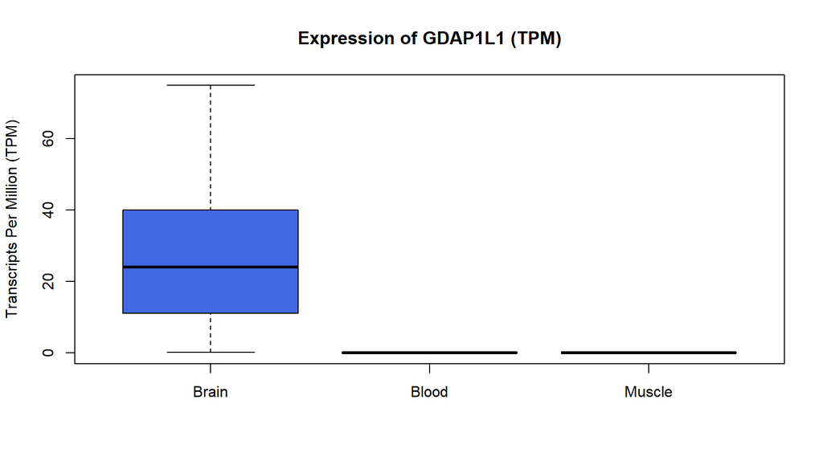

```r
assays(rse_brain)$TPM  <- recount::getTPM(rse_brain)
assays(rse_blood)$TPM  <- recount::getTPM(rse_blood)
assays(rse_muscle)$TPM <- recount::getTPM(rse_muscle)

idx <- which(rowData(rse_brain)$gene_name == brain_specific[1])

boxplot(
  assays(rse_brain)$TPM[idx, ],
  assays(rse_blood)$TPM[idx, ],
  assays(rse_muscle)$TPM[idx, ],
  outline = FALSE,
  names   = c("Brain", "Blood", "Muscle"),
  main    = paste("Expression of", brain_specific[1], "(TPM)"),
  ylab    = "Transcripts Per Million (TPM)",
  col     = c("royalblue", "firebrick", "forestgreen")
)
```

```r
wilcox.test(assays(rse_brain)$TPM[idx, ], assays(rse_blood)$TPM[idx, ])
```

```
##
##  Wilcoxon rank sum test with continuity correction
##
## data:  assays(rse_brain)$TPM[idx, ] and assays(rse_blood)$TPM[idx, ]
## W = 4097307, p-value < 2.2e-16
## alternative hypothesis: true location shift is not equal to 0
```

```r
wilcox.test(assays(rse_brain)$TPM[idx, ], assays(rse_muscle)$TPM[idx, ])
```

```
##
##  Wilcoxon rank sum test with continuity correction
##
## data:  assays(rse_brain)$TPM[idx, ] and assays(rse_muscle)$TPM[idx, ]
## W = 2582195, p-value < 2.2e-16
## alternative hypothesis: true location shift is not equal to 0
```

## Tissue-specific gene counts – barplot

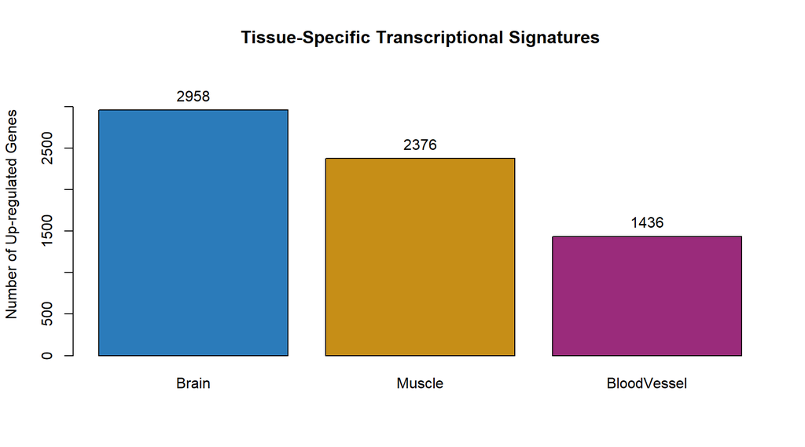

```r
tissue_counts <- c(
  Brain       = length(brain_specific),
  Muscle      = length(muscle_specific),
  BloodVessel = length(blood_specific)
)
tissue_counts <- sort(tissue_counts, decreasing = TRUE)

col_map    <- c(Brain = "#2b7bba", BloodVessel = "#9a2b7b", Muscle = "#c68e17")
bar_colors <- col_map[names(tissue_counts)]

bp <- barplot(tissue_counts,
              col  = bar_colors,
              main = "Tissue-Specific Transcriptional Signatures",
              ylab = "Number of Up-regulated Genes",
              ylim = c(0, max(tissue_counts) * 1.15))

text(x = bp, y = tissue_counts, labels = tissue_counts, pos = 3, cex = 1)
```

# 13 · Gene list preparation for Enrichr

Tissue-specific gene lists are pre-processed before functional enrichment analysis on **Enrichr** (https://maayanlab.cloud/Enrichr/). Two filtering steps are applied:

1. **Removal of low-information gene symbols**: pseudogenes (`LOC`), long intergenic non-coding RNAs (`LINC`), microRNAs (`MIR`), small nucleolar RNAs (`SNORD`), and ribosomal protein genes (`RPL`, `RPS`) are excluded. These either lack functional annotation in pathway databases or are too constitutively expressed to be informative as tissue markers.
2. **Size cap at 1,500 genes**: Enrichr’s statistical tests become less powerful with very large input lists. The top genes by FDR are therefore retained up to a maximum of 1,500.

```r
# Remove poorly informative gene symbols
rm_pattern <- "^LOC|^LINC|^MIR|^SNORD|^RPL|^RPS"

brain_specific_clean  <- brain_specific[ !grepl(rm_pattern, brain_specific)]
muscle_specific_clean <- muscle_specific[!grepl(rm_pattern, muscle_specific)]
blood_specific_clean  <- blood_specific[ !grepl(rm_pattern, blood_specific)]

# Sort by FDR and cap at 1500
ord  <- order(results_BvsBlood[ brain_specific_clean,  "FDR"])
brain_specific_top  <- brain_specific_clean[ord][1:min(1500, length(brain_specific_clean))]

ord2 <- order(results_MusclevsBrain[muscle_specific_clean, "FDR"])
muscle_specific_top <- muscle_specific_clean[ord2][1:min(1500, length(muscle_specific_clean))]

writeLines(brain_specific_top,  "brain_for_enrichr.txt")
writeLines(muscle_specific_top, "muscle_for_enrichr.txt")
writeLines(blood_specific_clean,"blood_for_enrichr.txt")

cat("Brain genes for Enrichr:",  length(brain_specific_top),  "\n")
```

```
## Brain genes for Enrichr: 1500
```

```r
cat("Muscle genes for Enrichr:", length(muscle_specific_top), "\n")
```

```
## Muscle genes for Enrichr: 1500
```

```r
cat("Blood genes for Enrichr:",  length(blood_specific_clean),"\n")
```

```
## Blood genes for Enrichr: 1272
```

*Analysis completed – 2026-10-15 11:10:50.880982*